# Dataset report: WBL

Jose Luis Delgado Davara

April 20, 2018

## Women, Business and the Law

**About the Data source:** Women, Business and the Law (WBL) is a World Bank Group project collecting unique data on the laws and regulations that restrict women’s economic opportunities. It measures gender equality in the law across 189 economies. The biennial report identifies legal barriers to women’s economic participation, encourages the reform of discriminatory laws and tracks global progress toward achieving gender equaility.Read more in this [link](http://wbl.worldbank.org/)*

**About the methodology:** Covering 189 economies, Women, Business and the Law provides comparable data across seven topics: Accessing institutions, Using property, Getting a job, Providing incentives to work, Going to court, Building credit and Protecting women from violence. The methodology was designed as an easily replicable benchmark of the legal environment for women as entrepreneurs and employees. To understand where laws facilitate or hinder gender equality and women’s economic participation, Women, Business and the Law 2018 provides scores for the first time for each of its seven topics. Scores are obtained by calculating the unweighted average of the scored questions within that topic, and scaling the result to 100.Read more about the methodology in this link or this [link](http://pubdocs.worldbank.org/en/356641522241086141/Data-Notes.pdf%22)*

## Quick view of the dataset

- Dataset dimensions

```
## [1] "Rows: 73984"
```

```
## [1] "Columns: 12"
```

- Countries

```
## [1] "Number of countries: 189"
```

- Years

```
## [1] 2018 2016 2014 2012 2010
```

- Numbers of indicators

```
## [1] "Number of indicators: 156"
```

- Values of indicators

```
##     Min.  1st Qu.   Median     Mean  3rd Qu.     Max.
##    0.000    0.000    1.000    6.129    1.000 1278.000
```

## Slide with Plot

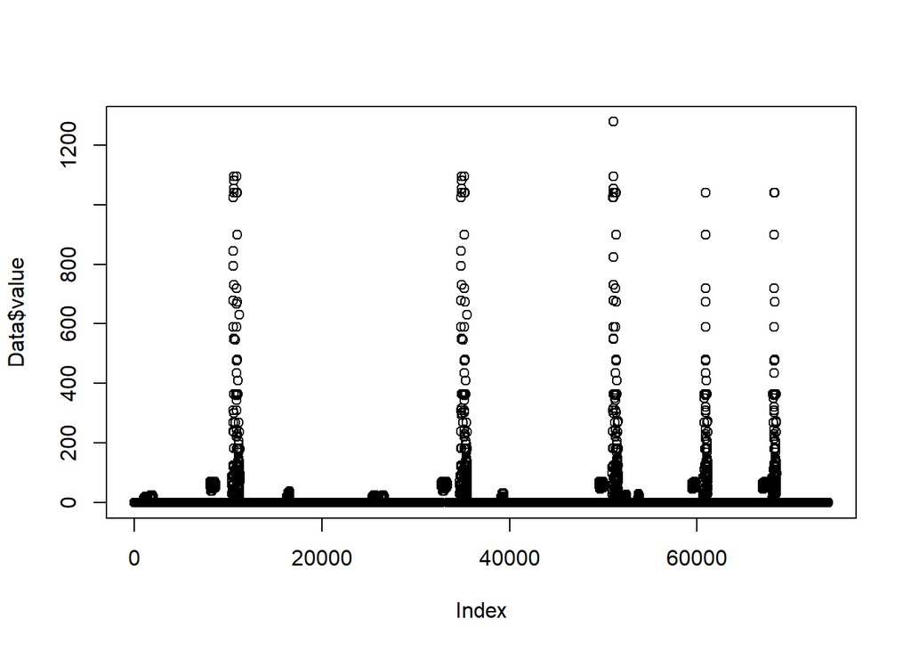

```r
plot(Data$value)
```

## Indicators

```r
unique(Data$question)
```

```
##   [1] Is there a specialized court or procedure for cases of domestic violence?
##   [2] Has legislation provided for the removal of provisions which exempt perpetrators from facing charges for rape if the perpetrator marries the victim after the crime?
##   [3] If there is no specific provision that explicitly criminalizes marital rape can a woman otherwise file a criminal complaint against her husband for rape?
##   [4] Does legislation explicitly criminalize marital rape?
##   [5] Are there penalties in the law for authorizing or knowingly entering into child or early marriage?
##   [6] Does the law prohibit or invalidate child or early marriage?
##   [7] What is the minimum age of marriage with judicial authorization for girls?
##   [8] What is the minimum age of marriage with judicial authorization for boys?
##   [9] What is the minimum age of marriage with parental consent for girls?
##  [10] What is the minimum age of marriage with parental consent for boys?
##  [11] Are there any exceptions to the legal age of marriage?
##  [12] What is the legal age of marriage for girls?
##  [13] What is the legal age of marriage for boys?
##  [14] Is there legislation on sexual harassment in public places?
##  [15] Is there legislation on sexual harassment in education?
```

[output cut: 142 more lines]